# Problem Statement: Concrete Strength Prediction

### Exploratory Data Quality Report Reflecting the Following:

- Univariate analysis –data types and description of the independent attributes which should include (name, range of values observed, central values (mean and median), standard deviation and quartiles, analysis of the body of distributions/tails, missing values, outliers, duplicates

Bi-variate analysis between the predictor variables and between the predictor variables and target column. Comment on your findings in terms of their relationship and degree of relation if any. Visualize the analysis using boxplots and pair plots, histograms, or density curves. (10 marks) Feature Engineering techniques(10 marks) Identify opportunities (if any) to extract new features from existing features, drop a feature(if required) Hint: Feature Extraction, for example, consider a dataset with two features length and breadth. From this, we can extract a new feature Area which would be length * breadth. Get the data model ready and do a train test split. Decide on the complexity of the model, should it be a simple linear model in terms of parameters or would a quadratic or higher degree.

```python
import pandas as pd # importing Pandas library for performing dataframe related operations
import numpy as np  # importing numpy for performing numeric array related operations
import matplotlib.pyplot as plt # importing matplotlib.pyplot for basic plotting operations
import seaborn as sns  # importing seaborn for advanced data visualization
# Below is the magic function to display and save graphs/figures in the output cells
%matplotlib inline
from sklearn.model_selection import train_test_split # For train-test split
# For standardizing/normalizing the data (let's import many and see which suits the best)
from sklearn.preprocessing import StandardScaler, MaxAbsScaler, MinMaxScaler, RobustScaler
from sklearn.preprocessing import PolynomialFeatures # To create polynomial features
import warnings # Import warnings module
warnings.filterwarnings('ignore') # Ignore the warnings
from sklearn.feature_selection import f_regression,SelectKBest,mutual_info_regression,RFE # For feature selection
# Let's import the various supervised ML models
from sklearn.linear_model import LinearRegression # Linear Regression model
from sklearn.neighbors import KNeighborsRegressor # K-NN Regressor Model
from sklearn.svm import SVR # Support vector regressor
from sklearn.tree import DecisionTreeRegressor # Decision tree regressor
# Let's import the ensemble regressor models
from sklearn.ensemble import AdaBoostRegressor,RandomForestRegressor,BaggingRegressor,GradientBoostingRegressor
from sklearn.pipeline import Pipeline # Import sklearn pipeline
from sklearn.model_selection import cross_val_score, KFold # Cross validation
from sklearn.metrics import explained_variance_score # Metric used to evaluate the regression models
from scipy.stats import zscore # zscore normalization from scipy.stats
from sklearn.utils import resample # Used to find the bootstrapping confidence interval
```

```python
dfConcrete = pd.read_csv('concrete.csv')
```

```python
dfConcrete.head()
```

|  | cement | slag | ash | water | superplastic | coarseagg | fineagg | age | strength |
| --- | --- | --- | --- | --- | --- | --- | --- | --- | --- |
| 0 | 141.3 | 212.0 | 0.0 | 203.5 | 0.0 | 971.8 | 748.5 | 28 | 29.89 |
| 1 | 168.9 | 42.2 | 124.3 | 158.3 | 10.8 | 1080.8 | 796.2 | 14 | 23.51 |
| 2 | 250.0 | 0.0 | 95.7 | 187.4 | 5.5 | 956.9 | 861.2 | 28 | 29.22 |
| 3 | 266.0 | 114.0 | 0.0 | 228.0 | 0.0 | 932.0 | 670.0 | 28 | 45.85 |
| 4 | 154.8 | 183.4 | 0.0 | 193.3 | 9.1 | 1047.4 | 696.7 | 28 | 18.29 |

```python
dfConcrete.shape
```

```
(1030, 9)
```

```python
dfConcrete.info()
```

```
<class 'pandas.core.frame.DataFrame'>
RangeIndex: 1030 entries, 0 to 1029
Data columns (total 9 columns):
 #   Column        Non-Null Count  Dtype
---  ------        --------------  -----
 0   cement        1030 non-null   float64
 1   slag          1030 non-null   float64
 2   ash           1030 non-null   float64
 3   water         1030 non-null   float64
 4   superplastic  1030 non-null   float64
 5   coarseagg     1030 non-null   float64
 6   fineagg       1030 non-null   float64
 7   age           1030 non-null   int64
 8   strength      1030 non-null   float64
dtypes: float64(8), int64(1)
memory usage: 72.5 KB
```

- There are no null values in any of the columns
- All the columns are numeric in nature
- There are 1030 rows and 9 columns

```python
dfConcrete[dfConcrete.duplicated()]
```

|  | cement | slag | ash | water | superplastic | coarseagg | fineagg | age | strength |
| --- | --- | --- | --- | --- | --- | --- | --- | --- | --- |
| 278 | 425.0 | 106.3 | 0.0 | 153.5 | 16.5 | 852.1 | 887.1 | 3 | 33.40 |
| 298 | 425.0 | 106.3 | 0.0 | 153.5 | 16.5 | 852.1 | 887.1 | 3 | 33.40 |
| 400 | 362.6 | 189.0 | 0.0 | 164.9 | 11.6 | 944.7 | 755.8 | 3 | 35.30 |
| 420 | 362.6 | 189.0 | 0.0 | 164.9 | 11.6 | 944.7 | 755.8 | 3 | 35.30 |
| 463 | 362.6 | 189.0 | 0.0 | 164.9 | 11.6 | 944.7 | 755.8 | 56 | 77.30 |
| 468 | 252.0 | 0.0 | 0.0 | 185.0 | 0.0 | 1111.0 | 784.0 | 28 | 19.69 |
| 482 | 425.0 | 106.3 | 0.0 | 153.5 | 16.5 | 852.1 | 887.1 | 91 | 65.20 |
| 493 | 362.6 | 189.0 | 0.0 | 164.9 | 11.6 | 944.7 | 755.8 | 91 | 79.30 |
| 517 | 425.0 | 106.3 | 0.0 | 153.5 | 16.5 | 852.1 | 887.1 | 56 | 64.30 |
| 525 | 362.6 | 189.0 | 0.0 | 164.9 | 11.6 | 944.7 | 755.8 | 28 | 71.30 |
| 527 | 425.0 | 106.3 | 0.0 | 153.5 | 16.5 | 852.1 | 887.1 | 91 | 65.20 |
| 576 | 362.6 | 189.0 | 0.0 | 164.9 | 11.6 | 944.7 | 755.8 | 7 | 55.90 |
| 577 | 425.0 | 106.3 | 0.0 | 153.5 | 16.5 | 852.1 | 887.1 | 28 | 60.29 |
| 604 | 362.6 | 189.0 | 0.0 | 164.9 | 11.6 | 944.7 | 755.8 | 56 | 77.30 |
| 733 | 362.6 | 189.0 | 0.0 | 164.9 | 11.6 | 944.7 | 755.8 | 91 | 79.30 |
| 738 | 362.6 | 189.0 | 0.0 | 164.9 | 11.6 | 944.7 | 755.8 | 28 | 71.30 |
| 766 | 362.6 | 189.0 | 0.0 | 164.9 | 11.6 | 944.7 | 755.8 | 91 | 79.30 |
| 830 | 425.0 | 106.3 | 0.0 | 153.5 | 16.5 | 852.1 | 887.1 | 7 | 49.20 |
| 880 | 425.0 | 106.3 | 0.0 | 153.5 | 16.5 | 852.1 | 887.1 | 56 | 64.30 |
| 884 | 425.0 | 106.3 | 0.0 | 153.5 | 16.5 | 852.1 | 887.1 | 7 | 49.20 |
| 892 | 362.6 | 189.0 | 0.0 | 164.9 | 11.6 | 944.7 | 755.8 | 56 | 77.30 |
| 933 | 362.6 | 189.0 | 0.0 | 164.9 | 11.6 | 944.7 | 755.8 | 7 | 55.90 |
| 943 | 362.6 | 189.0 | 0.0 | 164.9 | 11.6 | 944.7 | 755.8 | 3 | 35.30 |
| 967 | 362.6 | 189.0 | 0.0 | 164.9 | 11.6 | 944.7 | 755.8 | 28 | 71.30 |
| 992 | 425.0 | 106.3 | 0.0 | 153.5 | 16.5 | 852.1 | 887.1 | 28 | 60.29 |

```python
dfConcrete[dfConcrete.duplicated()].shape
```

```
(25, 9)
```

- There are 25 duplicate rows in the dataset, considering it to be about 2%, these can rows can left as is

### - Bi-variate analysis between the predictor variables and target column.

- Comment on your findings in terms of their relationship and degree of relation if any. Visualize the analysis using boxplots and pair plots, histograms, or density curves.

```python
dfConcrete.describe().T
```

|  | count | mean | std | min | 25% | 50% | 75% | max |
| --- | --- | --- | --- | --- | --- | --- | --- | --- |
| cement | 1030.0 | 281.167864 | 104.506364 | 102.00 | 192.375 | 272.900 | 350.000 | 540.0 |
| slag | 1030.0 | 73.895825 | 86.279342 | 0.00 | 0.000 | 22.000 | 142.950 | 359.4 |
| ash | 1030.0 | 54.188350 | 63.997004 | 0.00 | 0.000 | 0.000 | 118.300 | 200.1 |
| water | 1030.0 | 181.567282 | 21.354219 | 121.80 | 164.900 | 185.000 | 192.000 | 247.0 |
| superplastic | 1030.0 | 6.204660 | 5.973841 | 0.00 | 0.000 | 6.400 | 10.200 | 32.2 |
| coarseagg | 1030.0 | 972.918932 | 77.753954 | 801.00 | 932.000 | 968.000 | 1029.400 | 1145.0 |
| fineagg | 1030.0 | 773.580485 | 80.175980 | 594.00 | 730.950 | 779.500 | 824.000 | 992.6 |
| age | 1030.0 | 45.662136 | 63.169912 | 1.00 | 7.000 | 28.000 | 56.000 | 365.0 |
| strength | 1030.0 | 35.817961 | 16.705742 | 2.33 | 23.710 | 34.445 | 46.135 | 82.6 |

- There are no negative values in any of the columns.
- Cement looks evenly spread out
- Slag is heavily skewed to the right.
- Coarseagg and Fineagg is evenly distributed.

```
array([[<matplotlib.axes._subplots.AxesSubplot object at 0x000001FD22439460>,
      dtype=object)
```

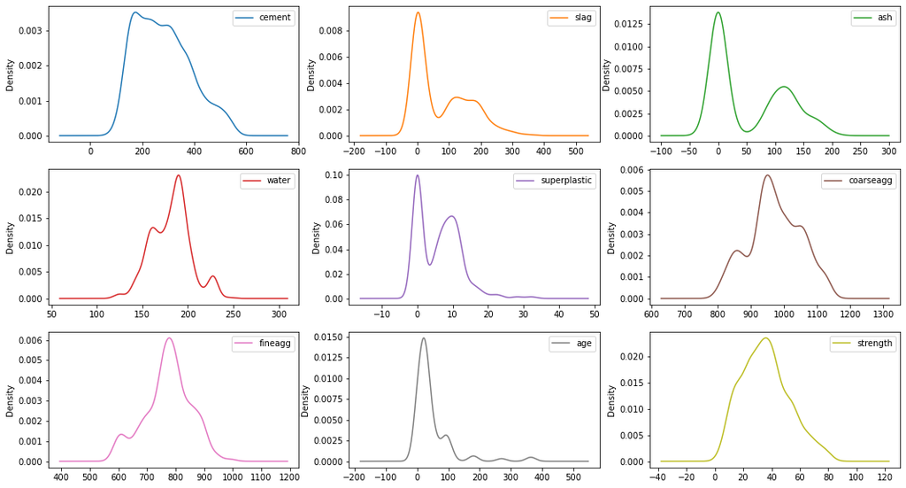

```python
dfConcrete.plot.kde(subplots = True, layout=(3,3), figsize=(18,10),sharex=False)
```

```python
dfConcrete.skew().sort_values(ascending=False)
```

```
age             3.269177
superplastic    0.907203
slag            0.800717
ash             0.537354
cement          0.509481
strength        0.416977
water           0.074628
coarseagg      -0.040220
fineagg        -0.253010
dtype: float64
```

- Age might have outliers, as it has a longer tail to the right
- Ash and Superplastic have multimodal distribution

```
cement             AxesSubplot(0.125,0.657941;0.227941x0.222059)
slag            AxesSubplot(0.398529,0.657941;0.227941x0.222059)
ash             AxesSubplot(0.672059,0.657941;0.227941x0.222059)
water              AxesSubplot(0.125,0.391471;0.227941x0.222059)
superplastic    AxesSubplot(0.398529,0.391471;0.227941x0.222059)
coarseagg       AxesSubplot(0.672059,0.391471;0.227941x0.222059)
fineagg               AxesSubplot(0.125,0.125;0.227941x0.222059)
age                AxesSubplot(0.398529,0.125;0.227941x0.222059)
strength           AxesSubplot(0.672059,0.125;0.227941x0.222059)
dtype: object
```

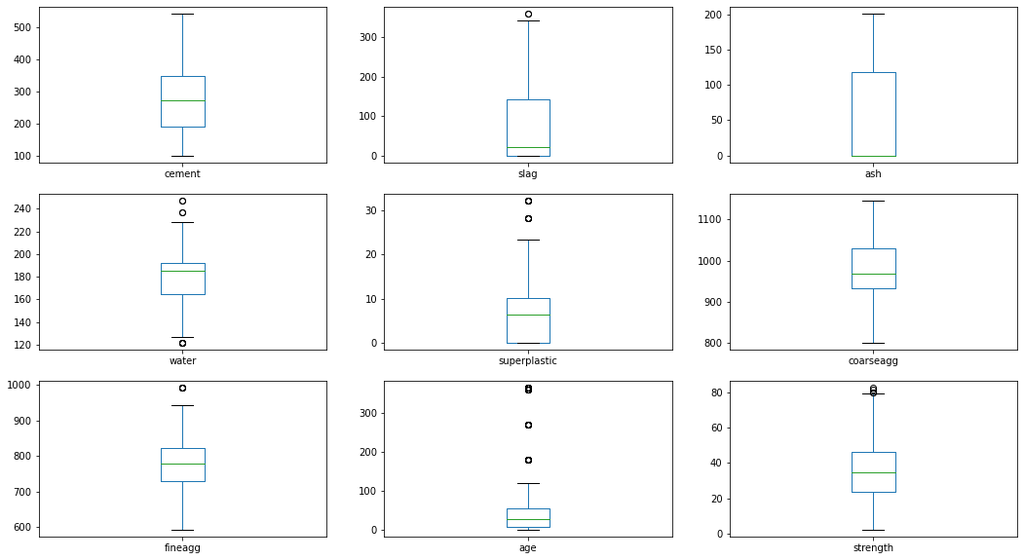

```python
dfConcrete.plot.box(subplots = True, layout=(3,3), figsize=(18,10),sharex=False)
```

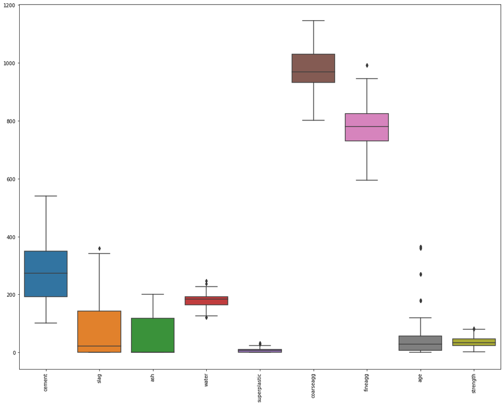

```python
plt.figure(figsize=(18,14))
box = sns.boxplot(data=dfConcrete)
box.set_xticklabels(labels=box.get_xticklabels(),rotation=90);
```

- Age shows high amount of outliers.
- Water shouls outliers on both side of whiskers
- Slag, fineagg also has outliers.

### Bi-variate analysis

- Comment on your findings in terms of their relationship and degree of relation if any. Visualize the analysis using boxplots and pair plots, histograms, or density curves.

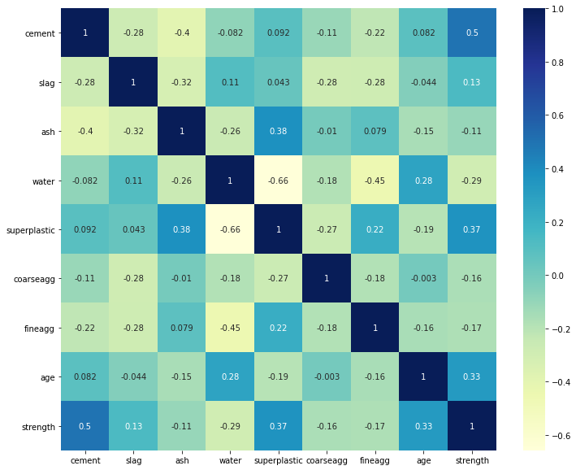

```python
plt.figure(figsize=(12,10))
sns.heatmap(dfConcrete.corr(),annot=True, cmap="YlGnBu")
```

- Target Strength and cement shows postive co-relation.
- Target Strength shows slight negative co-relation between water, fine agg and ash. So higher amount of water would mean lower the strength
- There a negative co-relation between water and super plastic

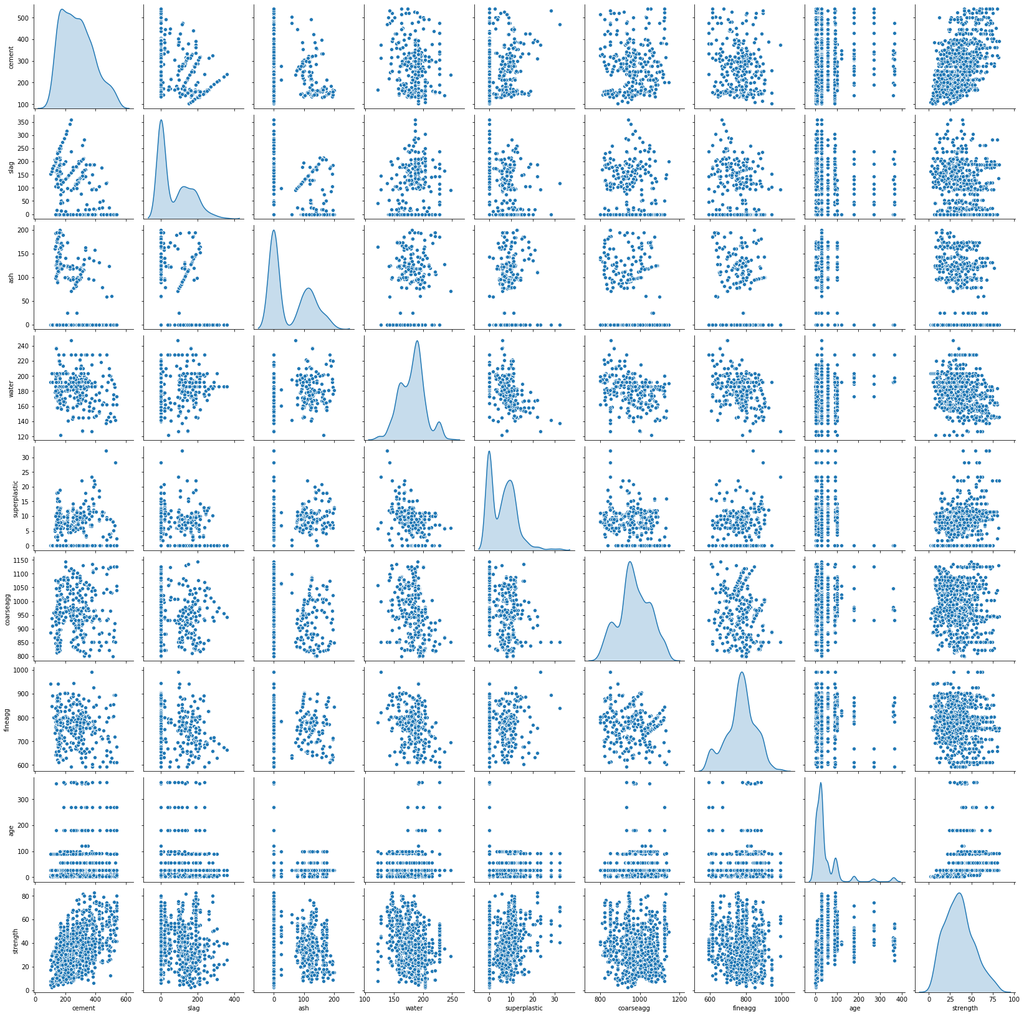

```python
sns.pairplot(dfConcrete,diag_kind='kde');
```

- Fineagg and coarseagg shows slight negative linear relationship with water
- Superplastic attribute has negative correlation with the water.

## 3. Feature Engineering techniques

#### 3.a Identify opportunities (if any) to create a composite feature, drop a feature¶

```python
dfConcrete.insert(8,'water/cement',dfConcrete['water']/dfConcrete['cement'])
# Let's check whether the feature is added properly or not?
dfConcrete.head()
```

|  | cement | slag | ash | water | superplastic | coarseagg | fineagg | age | water/cement | strength |
| --- | --- | --- | --- | --- | --- | --- | --- | --- | --- | --- |
| 0 | 141.3 | 212.0 | 0.0 | 203.5 | 0.0 | 971.8 | 748.5 | 28 | 1.440198 | 29.89 |
| 1 | 168.9 | 42.2 | 124.3 | 158.3 | 10.8 | 1080.8 | 796.2 | 14 | 0.937241 | 23.51 |
| 2 | 250.0 | 0.0 | 95.7 | 187.4 | 5.5 | 956.9 | 861.2 | 28 | 0.749600 | 29.22 |
| 3 | 266.0 | 114.0 | 0.0 | 228.0 | 0.0 | 932.0 | 670.0 | 28 | 0.857143 | 45.85 |
| 4 | 154.8 | 183.4 | 0.0 | 193.3 | 9.1 | 1047.4 | 696.7 | 28 | 1.248708 | 18.29 |

```python
dfConcrete.corr()
```

|  | cement | slag | ash | water | superplastic | coarseagg | fineagg | age | water/cement | strength |
| --- | --- | --- | --- | --- | --- | --- | --- | --- | --- | --- |
| cement | 1.000000 | -0.275216 | -0.397467 | -0.081587 | 0.092386 | -0.109349 | -0.222718 | 0.081946 | -0.879130 | 0.497832 |
| slag | -0.275216 | 1.000000 | -0.323580 | 0.107252 | 0.043270 | -0.283999 | -0.281603 | -0.044246 | 0.357322 | 0.134829 |
| ash | -0.397467 | -0.323580 | 1.000000 | -0.256984 | 0.377503 | -0.009961 | 0.079108 | -0.154371 | 0.246004 | -0.105755 |
| water | -0.081587 | 0.107252 | -0.256984 | 1.000000 | -0.657533 | -0.182294 | -0.450661 | 0.277618 | 0.332968 | -0.289633 |
| superplastic | 0.092386 | 0.043270 | 0.377503 | -0.657533 | 1.000000 | -0.265999 | 0.222691 | -0.192700 | -0.223215 | 0.366079 |
| coarseagg | -0.109349 | -0.283999 | -0.009961 | -0.182294 | -0.265999 | 1.000000 | -0.178481 | -0.003016 | -0.034255 | -0.164935 |
| fineagg | -0.222718 | -0.281603 | 0.079108 | -0.450661 | 0.222691 | -0.178481 | 1.000000 | -0.156095 | 0.066595 | -0.167241 |
| age | 0.081946 | -0.044246 | -0.154371 | 0.277618 | -0.192700 | -0.003016 | -0.156095 | 1.000000 | -0.029268 | 0.328873 |
| water/cement | -0.879130 | 0.357322 | 0.246004 | 0.332968 | -0.223215 | -0.034255 | 0.066595 | -0.029268 | 1.000000 | -0.500692 |
| strength | 0.497832 | 0.134829 | -0.105755 | -0.289633 | 0.366079 | -0.164935 | -0.167241 | 0.328873 | -0.500692 | 1.000000 |

#### Creating Data Model and splitting the data for training and testing.

```python
#df_orig.columns = dfConcrete['cement', 'slag', 'ash', 'water', 'superplastic', 'coarseagg', 'fineagg', 'age', 'strength']
# Let's create train and test sets
X = dfConcrete.drop('strength',axis=1)
y = dfConcrete['strength']
```

```python
X_train, X_test, y_train, y_test = train_test_split(X, y, test_size=0.3, random_state=42)
```

#### Setting up piples for following ML models

```python
df_result_raw_train = pd.DataFrame({'Regressor':[],'ExplVarianceScore':[],'StdDev':[]})
# We will use the pipeline approach
pipelines = []
#pipelines.append(('Linear Regression',Pipeline([('scaler',RobustScaler()),('LR',LinearRegression())])))
pipelines.append(('KNN Regressor',Pipeline([('scaler',RobustScaler()),('KNNR',KNeighborsRegressor())])))
pipelines.append(('SupportVectorRegressor',Pipeline([('scaler',RobustScaler()),('SVR',SVR())])))
pipelines.append(('DecisionTreeRegressor',Pipeline([('scaler',RobustScaler()),('DTR',DecisionTreeRegressor())])))
pipelines.append(('AdaboostRegressor',Pipeline([('scaler',RobustScaler()),('ABR',AdaBoostRegressor())])))
pipelines.append(('RandomForestRegressor',Pipeline([('scaler',RobustScaler()),('RBR',RandomForestRegressor())])))
pipelines.append(('BaggingRegressor',Pipeline([('scaler',RobustScaler()),('BGR',BaggingRegressor())])))
pipelines.append(('GradientBoostRegressor',Pipeline([('scaler',RobustScaler()),('GBR',GradientBoostingRegressor())])))
```

```python
for ind, val in enumerate(pipelines):
    # unpack the val
    name, pipeline = val
    kfold = KFold(n_splits=10,random_state=2020)
    cv_results = cross_val_score(pipeline, X_train, y_train, cv=kfold, scoring='explained_variance')
    df_result_raw_train.loc[ind] = [name,cv_results.mean()*100,cv_results.std()*100]
```

```python
df_result_raw_train
```

|  | Regressor | ExplVarianceScore | StdDev |
| --- | --- | --- | --- |
| 0 | KNN Regressor | 73.893876 | 7.777853 |
| 1 | SupportVectorRegressor | 71.781247 | 6.739393 |
| 2 | DecisionTreeRegressor | 84.051275 | 2.809507 |
| 3 | AdaboostRegressor | 79.837592 | 4.038441 |
| 4 | RandomForestRegressor | 90.431924 | 2.995280 |
| 5 | BaggingRegressor | 89.795197 | 3.131469 |
| 6 | GradientBoostRegressor | 90.598835 | 2.929324 |

```python
df_result_raw_test = pd.DataFrame({'Regressor':[],'ExplVarianceScore':[]})
for ind, val in enumerate(pipelines):
    # unpack the val
    name, pipeline = val
    pipeline.fit(X_train,y_train)
    y_pred = pipeline.predict(X_test)
    df_result_raw_test.loc[ind] = [name,explained_variance_score(y_test,y_pred)*100]
```

```python
df_result_raw_test
```

|  | Regressor | ExplVarianceScore |
| --- | --- | --- |
| 0 | KNN Regressor | 81.510866 |
| 1 | SupportVectorRegressor | 73.509981 |
| 2 | DecisionTreeRegressor | 88.272651 |
| 3 | AdaboostRegressor | 80.403713 |
| 4 | RandomForestRegressor | 91.172600 |
| 5 | BaggingRegressor | 89.891195 |
| 6 | GradientBoostRegressor | 90.549528 |

#### Tuning the model

a. Algorithms that you think will be suitable for this project b. Techniques employed to squeeze that extra performance out of the model without making it overfit or underfit c. Model performance range at 95% confidence level

```python
X = dfConcrete
y = dfConcrete['strength']
# Let's split into training and test datasets
X_train, X_test, y_train, y_test = train_test_split(X, y, test_size=0.2, random_state=42)
# Let's create dataframe to store the results.
df_result_mod_train = pd.DataFrame({'Regressor':[],'ExplVarianceScore':[],'StdDev':[]})
for ind, val in enumerate(pipelines):
    # unpack the val
    name, pipeline = val
    kfold = KFold(n_splits=10,random_state=2020)
    cv_results = cross_val_score(pipeline, X_train, y_train, cv=kfold, scoring='explained_variance')
    df_result_mod_train.loc[ind] = [name,cv_results.mean()*100,cv_results.std()*100]
# Let's check the training results with raw features  as well as new features
df_result_mod_train
```

|  | Regressor | ExplVarianceScore | StdDev |
| --- | --- | --- | --- |
| 0 | KNN Regressor | 90.435276 | 4.198300 |
| 1 | SupportVectorRegressor | 91.928800 | 2.981362 |
| 2 | DecisionTreeRegressor | 99.984193 | 0.009637 |
| 3 | AdaboostRegressor | 99.627696 | 0.078450 |
| 4 | RandomForestRegressor | 99.993454 | 0.003862 |
| 5 | BaggingRegressor | 99.990132 | 0.006767 |
| 6 | GradientBoostRegressor | 99.989602 | 0.002156 |

```python
# Let's find and store the cross-validation score for each pipeline for training data with raw as well as new features.
df_result_mod_test = pd.DataFrame({'Regressor':[],'ExplVarianceScore':[]})
for ind, val in enumerate(pipelines):
    # unpack the val
    name, pipeline = val
    pipeline.fit(X_train,y_train)
    y_pred = pipeline.predict(X_test)
    df_result_mod_test.loc[ind] = [name,explained_variance_score(y_test,y_pred)*100]
# Let's check the test results with raw features  as well as new features
df_result_mod_test
```

|  | Regressor | ExplVarianceScore |
| --- | --- | --- |
| 0 | KNN Regressor | 93.091737 |
| 1 | SupportVectorRegressor | 92.757300 |
| 2 | DecisionTreeRegressor | 99.972538 |
| 3 | AdaboostRegressor | 99.692132 |
| 4 | RandomForestRegressor | 99.969349 |
| 5 | BaggingRegressor | 99.965262 |
| 6 | GradientBoostRegressor | 99.972510 |

```python
X = dfConcrete.drop('strength',axis=1)
y = dfConcrete['strength']
# Let's split into training and test datasets
X_train, X_test, y_train, y_test = train_test_split(X, y, test_size=0.2, random_state=42)
# Creating pipelines for 3 best models.
pipe_rf = Pipeline([('scaler',RobustScaler()),('RBR',RandomForestRegressor())])
pipe_br = Pipeline([('scaler',RobustScaler()),('BGR',BaggingRegressor())])
pipe_gbr = Pipeline([('scaler',RobustScaler()),('GBR',GradientBoostingRegressor())])
# Initalize the empty dataframes to capture the feature importances given by these models..
df_featImp_rf = df_featImp_br = df_featImp_gbr = pd.DataFrame({'Features':[], 'Importance':[]})
```

```python
pipe_rf.fit(X_train,y_train)
featImp_rf = pipe_rf.steps[1][1].feature_importances_
df_featImp_rf['Features'] = X_train.columns
df_featImp_rf['Importance'] = featImp_rf
# Feature importance given by Random Forest Regressor
df_featImp_rf.sort_values(by='Importance', ascending=False)
```

|  | Features | Importance |
| --- | --- | --- |
| 7 | age | 0.357068 |
| 8 | water/cement | 0.351990 |
| 1 | slag | 0.086704 |
| 4 | superplastic | 0.047565 |
| 0 | cement | 0.043125 |
| 6 | fineagg | 0.038287 |
| 3 | water | 0.037691 |
| 5 | coarseagg | 0.023185 |
| 2 | ash | 0.014385 |

```python
pipe_gbr.fit(X_train,y_train)
featImp_gbr = pipe_gbr.steps[1][1].feature_importances_
df_featImp_gbr['Features'] = X_train.columns
df_featImp_gbr['Importance'] = featImp_gbr
# Feature importance given by Random Forest Regressor
df_featImp_gbr.sort_values(by='Importance', ascending=False)
```

|  | Features | Importance |
| --- | --- | --- |
| 7 | age | 0.388201 |
| 8 | water/cement | 0.335384 |
| 1 | slag | 0.098062 |
| 4 | superplastic | 0.049501 |
| 6 | fineagg | 0.038968 |
| 3 | water | 0.037391 |
| 0 | cement | 0.033985 |
| 5 | coarseagg | 0.015353 |
| 2 | ash | 0.003155 |

```python
cv = KFold(n_splits=5, random_state=10, shuffle=True)
cv_score = cross_val_score(model, X_test,y_test, scoring='neg_mean_squared_error', cv=cv, n_jobs=-1)
print ("The CV Accuracy = ",(cv_score*-1).mean())
```

[output not shown]

```python
## Computing 95% Confidence Interval
mean = (cv_score*-1).mean()
std = ((cv_score).std())
upper_limit = mean+(2*std)
lower_limit = mean-(2*std)
print("The 95% confidence range for test MSE values lies in [",lower_limit,",",upper_limit,"]")
```

```
The 95% confidence range for test MSE values lies in [ 27.29339390478001 , 97.98034847627667 ]
```

#### Summary and Conclusion¶

- Following ML Models were used to predict the compression strength
- KNN Regressor
- SupportVectorRegressor
- DecisionTreeRegressor
- AdaboostRegressor
- RandomForestRegressor
- BaggingRegressor
- GradientBoostRegressor